# Can machine learning predict risky sexual behavior?

Alonso Quijano

1/2/2020

# Introduction

## Motivation

This project was developed as part of the **edX Data Science Professional Programm** capstone project.

Latin America and the Caribbean are the regions with the second largest ratio of adolescent pregnancy in the world (Pan American Health Organization, 2016). Particularly in Ecuador, the adolescent birth rate is much higher than the regional average. While the rate in the region stands at 66.5 births per 1000 girls (15 to 19 years old), in Ecuador it is estimated at 76.5. (Minsiterio de Salud Publica del Ecuador, 2018). This is a major issue as many girls and adolescents must drop out of school to become young mothers, which has long-term repercussions in their health and the course of their lives. As a consequence, their educational and employment opportunities are affected, not to mention their psychological health and wellbeing (Pan American Health Organization, 2016).

Are parents aware of the sexual behavior of their children? At least in Ecuador, the answer is generally no. In fact, talking about sexuality is something many parents in Ecuador feel embarrassed about (Rodriguez, 2015). Additionally, they feel reluctant to leave the role of educating their children in these matters to schools and the government as demonstrated by the 2017 protests against education that promoted gender identity, which were supported by religious groups and were held in various cities of Ecuador. Their campaign slogan was: Don’t meddle with my children (El Comercio, 2017).

## Project’s objective

Although the use of condom can highly reduce the probability of getting STDs and avoid unwanted pregnancies, its use among teenagers, as well as the use of other contraception methods, is rare in Ecuador. How do teenagers decide when to start their sexual life, and how do they choose to use or not to use contraception? Although we may not be able to answer these questions robustly, we will deep dive into the factors that are correlated with a riskier sexual behavior, some of which are more obvious and some of which are less.

The objective of this project is to develop a machine-learning algorithm to predict risky sexual behavior on female adolescents in Ecuador. We want to identify the factors that can best predict sexual behavior and how they relate to the outcome. The goal is to create an algorithm that can be applied in the real world to identify the population more at risk of pregnancy. Therefore, by using strategic decision-making, we could help the government and organizations better direct programs and policies aimed to reduce teenage pregnancy, focusing on those who need them the most and saving time and other resources.

The idea of this project was inspired by the Poverty Probability Index (PPI), which is a poverty measurement tool created using machine-learning techniques. It is statistically-sound yet simple to use. By answering ten questions about a household’s characteristics and asset ownership, one can compute the likelihood that the household is living below the poverty line. Although it is not part of the scope of this project, our goal is also to design an index similar to the PPI, by creating a questionnaire that can be easily administered in schools or households to know the risk of pregnancy.

# The data

To elaborate the algorithm, we will use data from the Maternal and Child Health; and [Sexual and Reproductive Health Survey (ENSANUT)](https://www.ecuadorencifras.gob.ec/salud-salud-reproductiva-y-nutricion/) in Ecuador collected in 2018. The goal of this survey was to know the status of: fertility, maternal and child health, child nutrition, food consumption, access to food programs, physical activity, among other topics. The sample consists of approximately 48,700 women of childbearing age. Only adolescents from 12 to 18 and their mothers were included in our sample.

The ENSANUT dataset consists of several sub-datasets, which are described as follows:

- **f1_personas:** Demographic and economic data of each of the members of the household;
- **f1_hogar:** Data about the house the household lives in;
- **f2_mef:** Data about the sexual health of women from 10 to 49;
- **f4_fact_riesgo:** Data about behavioral risk factors of people from 5 to 18

The data is stored in different .dta document files. Along with the datasets, there are the questionnaires and the manuals for each survey. We used the questionnaires to identify the variables we were interested in and the manuals to know how they were categorized.

# The model

We used a logistic regression model. Logistic regression is the most commonly used generalized linear model (GLM). It is an extension of linear regression that assures that the estimate of $Pr(Y = 1 | X = x)$ is between 0 and 1 (Irizarry, 2019).

In this model, we define $Y$ as 1 for having or having had risky sexual behavior, and 0 for safe sexual behavior. $X$ are the explanatory variables or predictors that will be used to predict the likelihood of risky sexual behavior.

## The variables

### The predicted variable $Y$

We want to predict if a teenager is at risk of pregnancy or is already pregnant

1. The woman has ever been pregnant: **risk**
2. The woman has ever had intercourse and never used contraception: **risk**
3. The woman did not use contraception at first intercourse: **risk**
4. The woman did not use contraception at last intercourse: **risk**
5. The woman wouldn’t use contraception because does not like it: **risk**
6. The woman wouldn’t use contraception because is afraid of side effects: **risk**
7. The woman wouldn’t use contraception because the partner doesn’t like it: **risk**
8. The woman wouldn’t use contraception because she feels embarrassed: **risk**
9. The woman wouldn’t use contraception because of economic reasons: **risk**
10. The wouldn’t use contraception because she has no knowledge about contraception: **risk**
11. The woman wouldn’t use contraception because of other reasons or simply does not know why: **risk**
12. The rest: **no risk**

### The explanatory variables or predictors $X$

We considered variables from different dimensions: demographic, economic and social, educational (including sexual education), and behavioral

#### Demographic variables:

From now on, we will define the female teenagers as the “daughter” and their mothers as “mother” to make it clear who we are referring to.

- **age :** age of the daughter;
- **area :** area where the household is located (urban or rural);
- **ethnicity :** ethnicity of the daughter (indigenous, black, mestizo, white, etc.);
- **m.age :** age of the mother;
- **d.m.age.diff :** age difference between the mother and the daughter;
- **m.num.children :** number of children of the mother

### Economic and social variables:

- **num.bedrooms :** number of bedrooms in the house;
- **internet :** whether there is internet access in the house;
- **cellphone :** whether the daughter has an activated cellphone;
- **transfer :** whether someone in the household receives an economic transfer from the government;
- **m.job :** whether the mother has a job or not;
- **f.live.house:** whether the father lives in the house

### Educational variables (including those about sexual education):

- **attend.school :** whether the daughter attends school;
- **m.education :** mother’s education attainment (none, primary school, secondary school, university)

Variables related to sexual education:

- **contraception.info :** whether the daughter has ever received information about contraception;
- **contraception.info.family :** whether the daughter has learned about contraception mainly from her family;
- **contraception.info.school :** whether the daughter has learned about contraception mainly from school;
- **period.info :** whether the daughter knew about menstruation when she had her first period;
- **pregnancy.info :** whether the daughter can correctly answer the question: can a women get pregnant at first intercourse?;
- **aids.info :** whether the daughter can correctly answer the question: can AIDS be transmited through handshake?;
- **m.pregnancy.info :** whether the mother can correctly answer the question: can a women get pregnant at first intercourse?;
- **m.aids.info :** whether the mother can correctly answer the question: can AIDS be transmited through handshake?

### Behavioral variables:

- **intercourse :** whether the daughter has ever had intercourse;
- **alcohol :** whether the daughter has ever drunk alcohol;
- **alcohol.recent :** whether the daughter has drunk alcohol in the past 30 days;
- **smoke :** whether the daughter has ever smoked;
- **smoke.recent :** whether the daughter has smoked in the past 30 days;
- **m.age.first.intercourse :** mother’s age at first intercourse;
- **m.contraception:** mother’s use of contraception (is using, has ever used, has never used)

## Analyzing the data

Firstly, we need to load the libraries we will use to analyze the data and create the algorithm.

```r
library(tidyverse)
library(gridExtra)
library(caret)
```

We will load the data from Github. Note that we have already transformed the data from “raw” data to “tidy” data. We can check the appendix of this report for more detail about the data wrangling process.

```r
# We will load the data from Github and check the variables using the str function.
githubURL <- "https://github.com/aquijanoruiz/HarvardX_capstone/raw/master/SexRisk/pregnancy_risk.rds"
preg.risk <- readRDS(url(githubURL))
str(preg.risk)
```

```
## 'data.frame':    8607 obs. of  38 variables:
##  $ id.subject                 : chr  "01015000020103105" "01015000020104104" "01015000020104105" "01015000020104106" ...
##  $ id.household               : chr  "010150000201031" "010150000201041" "010150000201041" "010150000201041" ...
##  $ id.mother                  : chr  "01015000020103102" "01015000020104102" "01015000020104102" "01015000020104102" ...
##  $ contraception              : Factor w/ 4 levels "is using","has ever used",..: 4 3 1 4 4 4 4 4 4 4 ...
##  $ contraception.no.use.reason: Factor w/ 14 levels "wants to get pregnant",..: NA 9 NA NA 3 NA NA NA NA 3 ...
##  $ contraception.first        : Factor w/ 3 levels "yes","no","no sex": 3 2 2 3 3 3 3 3 3 3 ...
##  $ contraception.last         : Factor w/ 3 levels "yes","no","no sex": 3 2 2 3 3 3 3 3 3 3 ...
##  $ pregnant                   : Factor w/ 2 levels "yes","no": 2 1 2 2 2 2 2 2 2 2 ...
##  $ age                        : int  18 18 15 12 16 18 13 13 13 18 ...
##  $ area                       : Factor w/ 2 levels "urban","rural": 1 1 1 1 1 1 1 1 1 1 ...
##  $ ethnicity                  : Factor w/ 8 levels "indigenous","african ecuadorian",..: 6 6 6 6 6 6 6 6 6 1 ...
##  $ m.age                      : int  42 38 38 38 42 40 38 38 40 44 ...
##  $ d.m.age.diff               : int  24 20 23 26 26 22 25 25 27 26 ...
##  $ num.bedrooms               : int  3 4 4 4 2 3 3 3 3 3 ...
```

[output cut: 24 more lines]

### Demographic variables

- **age**

We can see the risk of pregnancy starts appearing as the age increases.

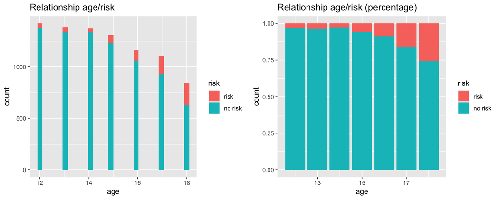

```r
age.plot1 <- preg.risk %>% ggplot(aes(age, fill = risk)) +
  geom_histogram() + ggtitle("Relationship age/risk")

age.plot2 <- preg.risk %>% ggplot(aes(age, fill = risk)) +
  geom_bar(position = "fill") + ggtitle("Relationship age/risk (percentage)")

grid.arrange(age.plot1,age.plot2,ncol=2)
```

```r
chisq.test(preg.risk$age, preg.risk$risk) # the chi square test shows it's true
```

```
FALSE
FALSE   Pearson's Chi-squared test
FALSE
FALSE data:  preg.risk$age and preg.risk$risk
FALSE X-squared = 587.91, df = 6, p-value < 2.2e-16
```

- **area**

We are not sure if the area has a significant correlation with the risk of pregnancy. There doesn’t seem to be one.

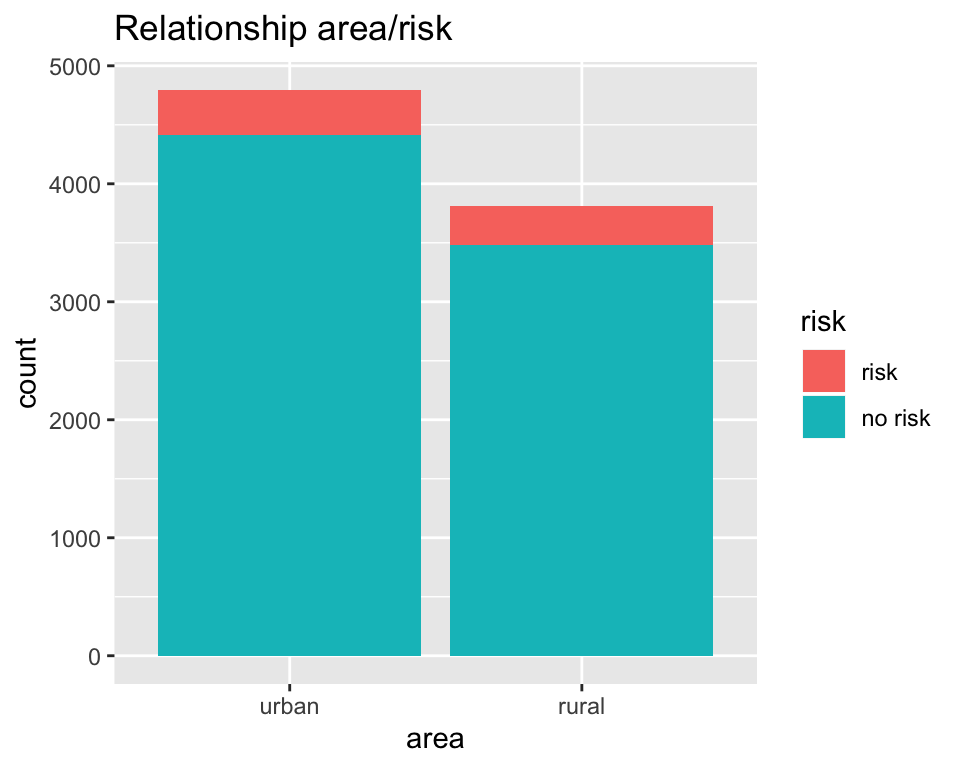

```r
preg.risk %>% ggplot(aes(area, fill = risk)) +
  geom_bar() + ggtitle("Relationship area/risk")
```

```r
chisq.test(preg.risk$area, preg.risk$risk) # we can't reject the null
```

```
FALSE
FALSE   Pearson's Chi-squared test with Yates' continuity correction
FALSE
FALSE data:  preg.risk$area and preg.risk$risk
FALSE X-squared = 1.4422, df = 1, p-value = 0.2298
```

- **ethnicity**

It also doesn’t seem to be a problem of ethnicity.

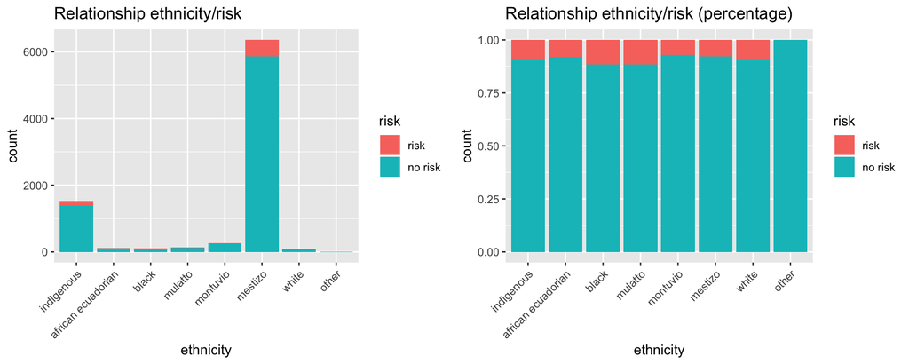

```r
ethnicity.plot1 <- preg.risk %>% ggplot(aes(ethnicity, fill = risk)) +
  geom_bar() + ggtitle("Relationship ethnicity/risk") +
  theme(axis.text.x = element_text(angle = 45, hjust = 1))

ethnicity.plot2 <- preg.risk %>% ggplot(aes(ethnicity, fill = risk)) +
  geom_bar(position = "fill") + ggtitle("Relationship ethnicity/risk (percentage)") +
  theme(axis.text.x = element_text(angle = 45, hjust = 1))

grid.arrange(ethnicity.plot1,ethnicity.plot2,ncol=2)
```

```r
chisq.test(preg.risk$ethnicity, preg.risk$risk) # we can't reject the null
```

```
FALSE
FALSE   Pearson's Chi-squared test
FALSE
FALSE data:  preg.risk$ethnicity and preg.risk$risk
FALSE X-squared = 10.492, df = 7, p-value = 0.1624
```

- **d.m.age.diff**

It looks like very small and very large age differences between the daughter and the mother affect the risk.

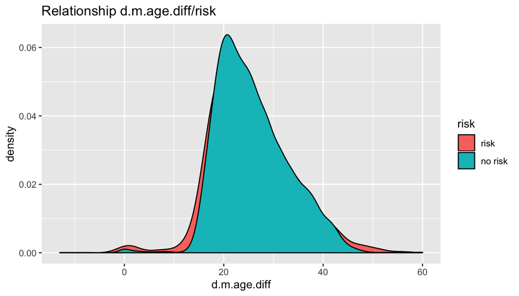

```r
preg.risk %>% ggplot(aes(d.m.age.diff, fill = risk)) +
  geom_density() + ggtitle("Relationship d.m.age.diff/risk")
```

### Economic and social variables

- **n.bedrooms, internet, cellphone, transfer**

The risk of pregnancy seesms to be correlated to income level.

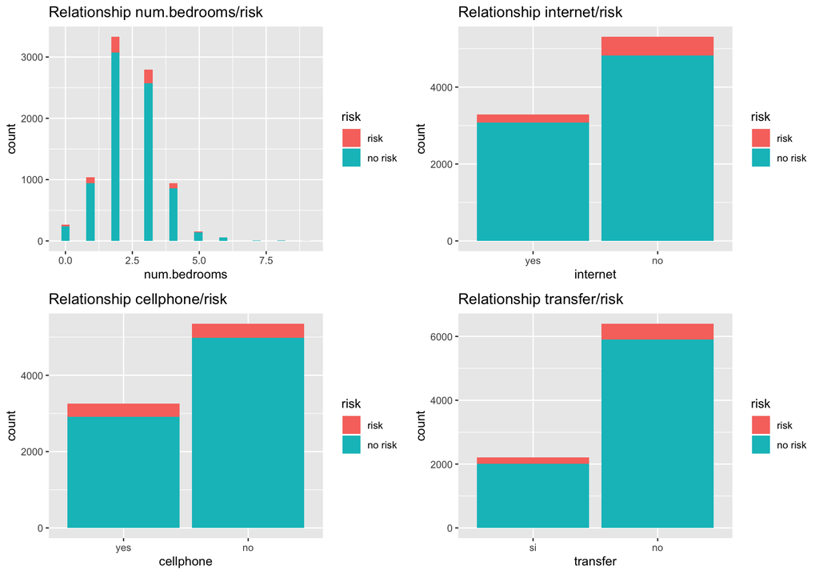

```r
num.bedrooms.plot <- preg.risk %>% ggplot(aes(num.bedrooms, fill = risk)) +
  geom_histogram() + ggtitle("Relationship num.bedrooms/risk")

internet.plot <- preg.risk %>% ggplot(aes(internet, fill = risk)) +
  geom_bar() + ggtitle("Relationship internet/risk")

cellphone.plot <- preg.risk %>% ggplot(aes(cellphone, fill = risk)) +
  geom_bar() + ggtitle("Relationship cellphone/risk")

transfer.plot <- preg.risk %>% ggplot(aes(transfer, fill = risk)) +
  geom_bar() + ggtitle("Relationship transfer/risk")

grid.arrange(num.bedrooms.plot, internet.plot, cellphone.plot, transfer.plot, nrow=2, ncol=2)
```

```r
chisq.test(preg.risk$internet, preg.risk$risk)$p.value # we reject the null
```

```
FALSE [1] 2.33266e-05
```

```r
chisq.test(preg.risk$cellphone, preg.risk$risk)$p.value  # we reject the null
```

```
FALSE [1] 1.360221e-08
```

```r
chisq.test(preg.risk$transfer, preg.risk$risk)$p.value  # there seems to be a correlation
```

```
FALSE [1] 0.04004721
```

```r
chisq.test(preg.risk$num.bedrooms, preg.risk$risk)$p.value  # the approximation may be incorrect
```

```
FALSE [1] 0.1506078
```

- **f.live.house**

Whether the father lives in the house or not (having a single-parent household) seems to be correlated with the risk of pregnancy. Although it is not so clear from the graph, the chi-square test shows there appears to be an association.

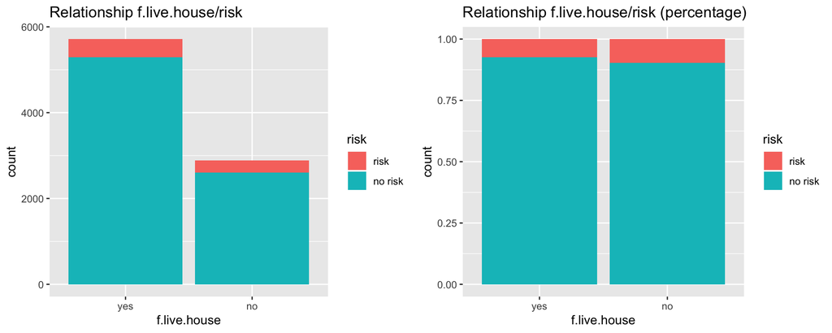

```r
f.live.house.plot1 <- preg.risk %>% ggplot(aes(f.live.house, fill = risk)) +
  geom_bar() + ggtitle("Relationship f.live.house/risk")

f.live.house.plot2 <- preg.risk %>% ggplot(aes(f.live.house, fill = risk)) +
  geom_bar(position = "fill") + ggtitle("Relationship f.live.house/risk (percentage)")

grid.arrange(f.live.house.plot1, f.live.house.plot2, ncol=2)
```

```r
chisq.test(preg.risk$f.live.house, preg.risk$risk) # we reject the null
```

```
FALSE
FALSE   Pearson's Chi-squared test with Yates' continuity correction
FALSE
FALSE data:  preg.risk$f.live.house and preg.risk$risk
FALSE X-squared = 14.41, df = 1, p-value = 0.0001471
```